# BLAST

Bin He

07/01/2020 (updated: 2022-04-27)

This analysis accompanies the BLAST search to identify homologs for XP_028889033

```r
suppressPackageStartupMessages(library(tidyverse))
# install rentrez package if not already installed
if (!requireNamespace("rentrez", quietly = TRUE))
    install.packages("rentrez")
suppressPackageStartupMessages(library(rentrez))
# set NCBI Entrez API key
set_entrez_key("f4f01c220f3a0a162bada5b0bd5d4b131908")
# install seqinr package if not already installed
if (!requireNamespace("seqinr", quietly = TRUE))
    install.packages("seqinr")
suppressPackageStartupMessages(library(seqinr))
suppressPackageStartupMessages(library(XML))
```

## Refseq_protein

I used blastp to search the N-terminal 560 residues in XP_028889033 against the refseq_protein database. (See README.md for details). The taxonomy distribution is shown below:

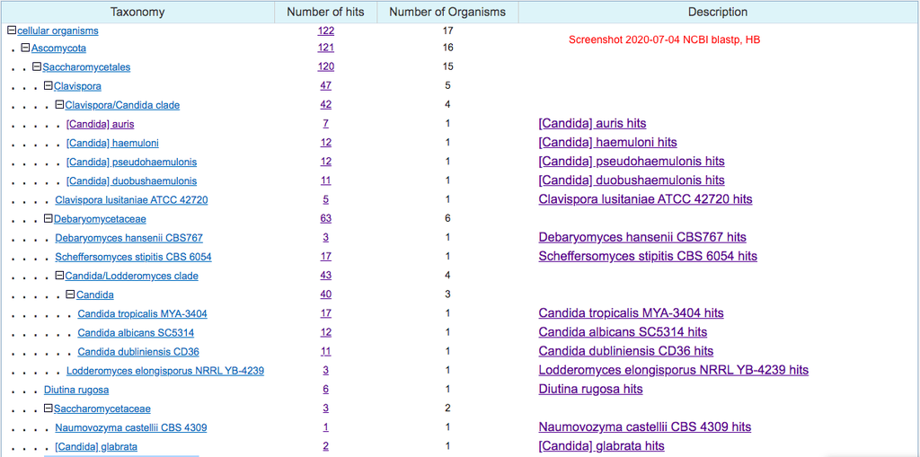

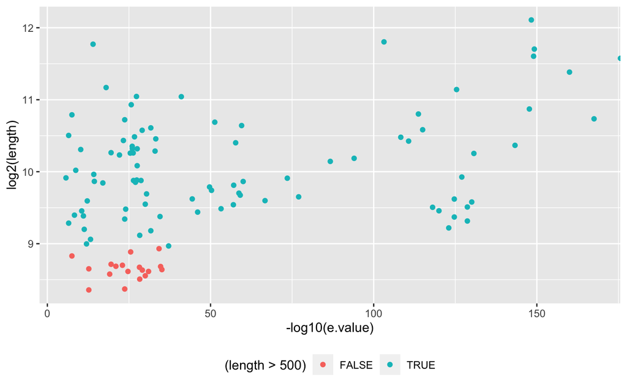

```r
# load table
refseq <- read_csv("data/ncbi-refseq/XP_028889033_homologs_refprot_N560_select.csv", col_types = "cddnnnc")
refseq.length <- read_tsv("data/ncbi-refseq/XP_028889033_homologs_refprot_N560_select_length.txt", col_names = c("accession","length"), col_types = "ci")
refseq <- left_join(refseq, refseq.length) %>% select(accession, everything())
# Do the refseq hits show similar relationship between e-value and protein length?
refseq %>%
  ggplot(aes(x = -log10(e.value), y = log2(length), col = (length > 500))) + geom_point() +
  theme(legend.position = "bottom")
ggsave("img/20200723-XP_028889033-refseq-hits-e-value-by-length.png", width = 3, height = 3)
```

```r
# The answer is yes. So let's filter these out and show what they are
refseq0 <- refseq %>%
  filter(length > 500, !grepl("rugosa", description))
refseq %>% filter(length <= 500) %>% select(accession, query.cover, e.value, perc.ident, length, description)
```

| accession | query.cover | e.value | perc.ident | length | description |
| --- | --- | --- | --- | --- | --- |
| XP_001386767.2 | 56 | 8e-36 | 34.87 | 399 | hyphally regulated cell wall protein [Scheffersomyces stipitis CBS 6054] |
| XP_001383276.2 | 57 | 2e-35 | 32.36 | 411 | hypothetical protein PICST_43205 [Scheffersomyces stipitis CBS 6054] |
| XP_001387297.2 | 56 | 6e-35 | 33.43 | 488 | hyphally regulated cell wall protein [Scheffersomyces stipitis CBS 6054] |
| XP_001386047.2 | 57 | 1e-31 | 31.04 | 392 | hyphally regulated cell wall protein Exo-alpha-sialidase [Scheffersomyces stipitis CBS 6054] |
| XP_034010991.1 | 55 | 1e-30 | 31.40 | 376 | uncharacterized protein DIURU_004257 [Diutina rugosa] |
| XP_001387240.2 | 56 | 8e-30 | 31.07 | 397 | hyphally regulated cell wall protein [Scheffersomyces stipitis CBS 6054] |
| XP_034010684.1 | 50 | 5e-29 | 32.99 | 364 | uncharacterized protein DIURU_004501 [Diutina rugosa] |
| XP_001385682.2 | 55 | 6e-29 | 32.42 | 408 | hyphally regulated cell wall protein [Scheffersomyces stipitis CBS 6054] |
| XP_001386218.2 | 56 | 3e-26 | 32.16 | 473 | hyphally regulated cell wall protein [Scheffersomyces stipitis CBS 6054] |
| XP_001382756.2 | 55 | 2e-25 | 32.83 | 392 | hyphally regulated cell wall protein [Scheffersomyces stipitis CBS 6054] |

[output cut: 8 more lines]

```r
# the above script uses a strange way to move a column to the last, by first removing it and then adding it back
# thanks to https://github.com/tidyverse/dplyr/issues/3051
```

*Discussion*

1. We see that the excluded sequences not only have less significant e-values, but also have barely above 50% query coverage. In terms of species distribution, most of them are from *S. stipitis* and *D. rugosa*. The second species will be removed anyways (see notes in the `03-gene-tree` folder)
2. Even though a couple of the *S. stipitis* sequences were annotated as “fungal hyphal regulated cell wall proteins”, with less than 500 a.a., they are unlikely to encode the stalk and in a separate analysis, I also found them to not possess the GPI-anchor. All in all, I think these sequences are unlikely to be candidate adhesins.

### NCBI blastp with N360 query

I repeated the NCBI blastp search with the first 360 amino acid residues instead of the first 560. Because the 560 aa sequence contains a copy of the Hyr1 domain in addition to the PF11765 domain, it is possible that some of the hits bear similarity to the Hyr1 and not the Hyphal_reg_CWP domain. Also, when I applied the >50% query coverage filter on the resulting homolog list, the effective cutoff for the PF11765 domain would be higher, since most of the hits don’t share the Hyr1 domain.

Below is the taxonomy distribution of the hits:

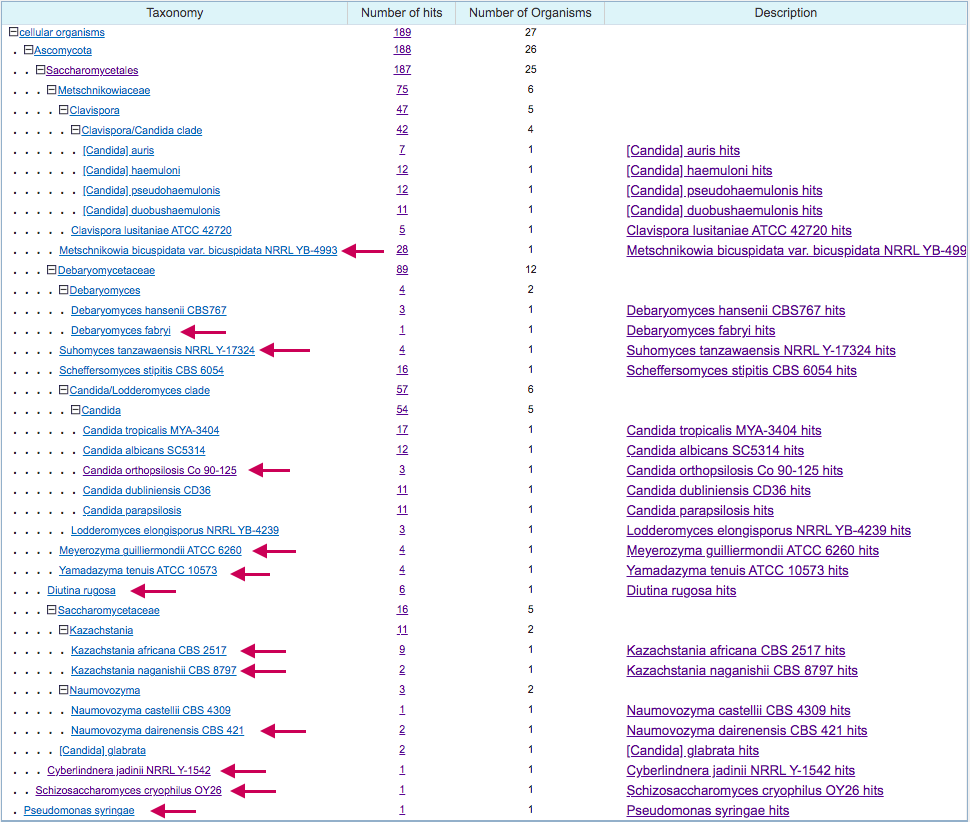

To determine the effect of changing the query sequence from N560 to N360 amino acids, I downloaded the hits description and the fasta sequences from both searches. Now let’s compare them.

```r
hitTabColNames <- c("description","sci.name","common.name","taxid","max.score",
                    "total.score","query.cover","e.value","perc.ident","length","acc")
refseq.N360 <- read_csv("data/ncbi-refseq/XP_028889033_homologs_refprot_N360.csv",  col_types = "ccccddcddic", col_names = hitTabColNames, skip = 1) %>%
  mutate(query.cover = parse_number(query.cover),
         accession = gsub('[")]','',str_split(acc, ",", simplify = T)[,2]))

cat("**Sequences only in the N360 set after applying the 50% query coverage filter**")
```

**Sequences only in the N360 set after applying the 50% query coverage filter**

```r
all.N360 <- refseq.N360 %>% filter(query.cover >= 50, length > 500) %>% pull(accession)
only.in.N360 <- setdiff(all.N360, refseq0$accession)
refseq.N360 %>% filter(accession %in% only.in.N360) %>%
  select(accession, qcov = query.cover, e.value, pident = perc.ident, length, sci.name) %>%
  arrange(sci.name)
```

| accession | qcov | e.value | pident | length | sci.name |
| --- | --- | --- | --- | --- | --- |
| XP_024716365.1 | 71 | 7e-89 | 62.16 | 2268 | [Candida] pseudohaemulonis |
| XP_717775.2 | 58 | 9e-09 | 27.31 | 1244 | Candida albicans SC5314 |
| XP_003868553.1 | 88 | 2e-29 | 32.07 | 706 | Candida orthopsilosis Co 90-125 |
| XP_003868554.1 | 89 | 1e-27 | 31.41 | 857 | Candida orthopsilosis Co 90-125 |
| XP_003868555.1 | 80 | 2e-10 | 25.16 | 774 | Candida orthopsilosis Co 90-125 |
| XP_036665264.1 | 87 | 2e-26 | 32.06 | 1671 | Candida parapsilosis |
| XP_002547616.1 | 56 | 2e-12 | 30.09 | 1626 | Candida tropicalis MYA-3404 |
| XP_002545510.1 | 50 | 9e-12 | 29.95 | 656 | Candida tropicalis MYA-3404 |
| XP_002614115.1 | 76 | 3e-08 | 30.33 | 780 | Clavispora lusitaniae ATCC 42720 |
| XP_002770240.1 | 69 | 4e-11 | 33.92 | 949 | Debaryomyces hansenii CBS767 |

[output cut: 18 more lines]

```r
cat("**Sequences only in the N560 set after applying the 50% query coverage filter**")
```

**Sequences only in the N560 set after applying the 50% query coverage filter**

```r
only.in.N560 <- setdiff(refseq0$accession, all.N360)
refseq0 %>% filter(accession %in% only.in.N560) %>%
  select(accession, qcov = query.cover, e.value, pident = perc.ident, length)
```

| accession | qcov | e.value | pident | length |
| --- | --- | --- | --- | --- |
| XP_001383953.2 | 58 | 3e-07 | 26.3 | 1452 |

*Discussion*

One sequence from the original blast search, XP_001383953.2 from *S. stipitis* didn’t make the cut in the new search. When I lowered the e-value cutoff to 1e-3, it appeared at the bottom of the hist list. For consistency’s sake, I decided to exclude it from the new analysis.

At the same time, I found that **relaxing the e-value cutoff from 1e-5 to 1e-3 only resulted in four new sequences**. This suggests that the list of homologs is not too sensitive to the arbitrary choice of the e-value cutoff. Looking at the three other sequences making the cut at 1e-3, one is from a species I am not including anyway. The other two were actually added from the FungiDB search result (see notes and analysis below). This made me realize that **e-value cutoff is database-size-specific** and thus using the same cutoff doesn’t mean the same thing between refseq_db, fungidb and GRYC. But the resulting differences in the number of hits included or excluded are relatively small and thus don’t affect the overall conclusions.

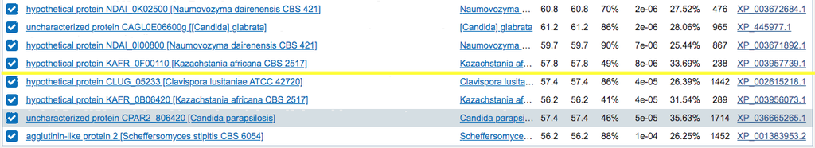

```r
refseq.add <- c("XP_024716365.1", "XP_717775.2", "XP_036665264.1", "XP_002547616.1", "XP_002545510.1", "XP_002614115.1", "XP_002770240.1")
# remove one seq, see notes above
refseq0 <- refseq0 %>% filter(accession != "XP_001383953.2")
refseq.combined <- refseq.N360 %>%
  filter(accession %in% refseq.add) %>%
  select(accession, description, max.score, total.score, query.cover, e.value, perc.ident, length) %>%
  bind_rows(refseq0)
```

### Missing homolog in *C. auris* B11221

*Update 2021-03-01*

Muñoz et al 2021 reported 8 members in the Iff/Hyr1 family in *C. auris* clades I and III.

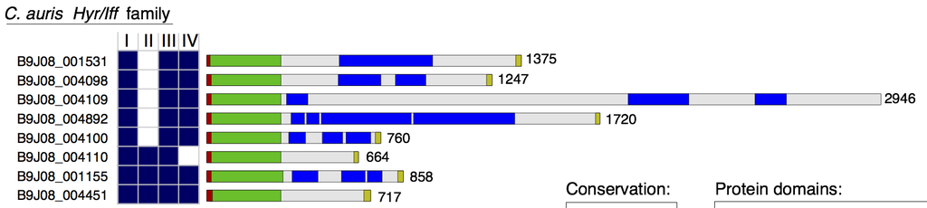

Muñoz et al 2021 Fig. 5a, C. auris clade I and III have 8 members

My own blastp only identified 7 members in the refseq_prot database, which includes B11221 but not B8441. A second blastp search against the nr_prot database, with taxonomy restricted to *C. auris* confirmed that while B8441 showed 8 hits, B11221 only showed 7. This is inconsistent with the Muñoz 2021 report. The discrepancy could be due to the protein fasta file in the B11221 refseq assembly being incomplete. To keep our results consistent with the recent publication, I’ll add this one B8441 sequence to the homolog database manually so we would have 8 members, which is the max size of the family among all know *C. auris* strains. Although, note that the 8 genes do not all come from the same strain any more. I don’t expect this to change any of our downstream analyses, since the two strains are closely related within the same clade in *C. auris*.

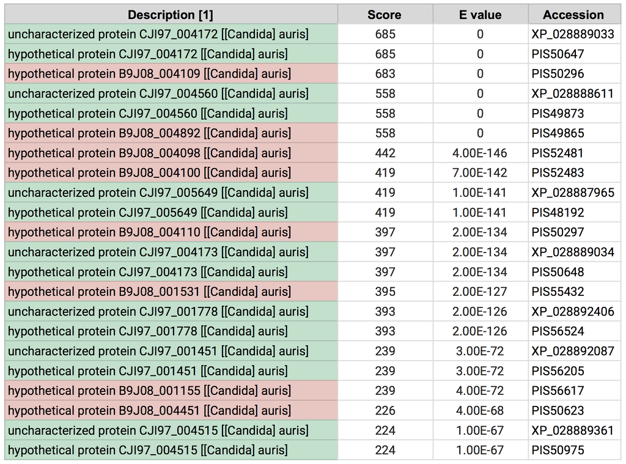

B11221 is missing one sequence

## Fungidb

### Update 2021-01-24 [HB] new search with N360 aa

I repeated the search with either N360 or N560 aa, with e-value 1e-5 cutoff and low complexity filter on. The first search yielded 104 hits and the second 105. I downloaded the results from the first search and named them with “N360” in their filenames. Below I will compare the list to my previous list.

```r
# old: load table
fungidb <- read_tsv("data/fungidb/XP_028889033_homologs_fungidb_N560_table.tsv", col_types = "cccddcccdcc")
fungidb$species_id <- map_chr(str_split(fungidb$organism, " "), function(x) paste0(substr(x[1],1,1), x[2]))
# new: load table
fungidb.new <- read_tsv("data/fungidb/XP_028889033_homologs_fungidb_N360_table.tsv", col_types = "cccddcccccccd")
fungidb.new$species_id <- map_chr(str_split(fungidb.new$organism, " "), function(x) paste0(substr(x[1],1,1), x[2]))
# reveal differences
cat("**sequences in the original list but not in the new one**")
```

**sequences in the original list but not in the new one**

```r
setdiff(fungidb$gene_id, fungidb.new$gene_id)
```

[1] “CAGL0L00227g” “CPAR2_600430”

```r
cat("**sequences in the new list but not in the old one**")
```

**sequences in the new list but not in the old one**

```r
setdiff(fungidb.new$gene_id, fungidb$gene_id)
```

[1] “CAWG_00106” “CAWG_01420” “CAWG_01434” “CAWG_01699” “CAWG_01724” “CAWG_02393” [7] “CAWG_02395” “CAWG_03173” “CAWG_04465” “CAWG_04466” “CAWG_05662”

*Discussion*

Using the N360 as query resulted in two fewer hits, one of which was excluded anyway later, i.e. CAGL0L00227g, while the other one probably just went slightly below the e-value cutoff. By contrast, using the N360 didn’t result in any new hits (the CAWG ones are from the WO-1 strain of *C. albicans*). However, I should pay attention to the query coverage filter used below.

### Filtering fungidb hits by length

Some of the identified homologs have less than 500 amino acids. I want to know if these hits also tend to have less significant *e-values*. If so, I’ll exclude them from further analyses.

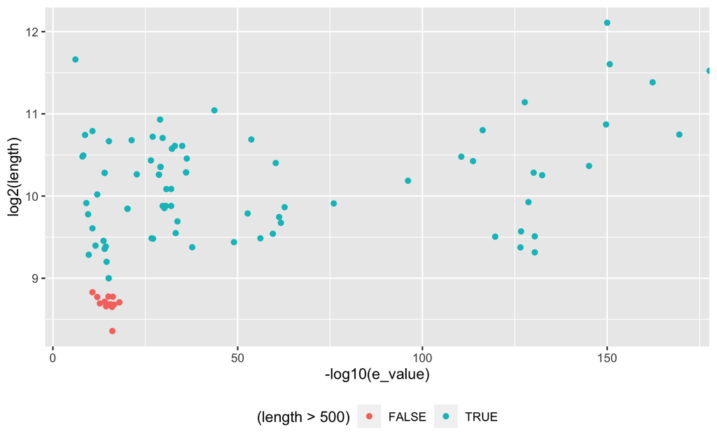

```r
# plot protein length as a function of e-value
fungidb %>%
  ggplot(aes(x = -log10(e_value), y = log2(length), col = (length > 500))) + geom_point() +
  theme(legend.position = "bottom")
ggsave("img/20200701-XP_028889033-fungidb-hits-e-value-by-length.png", width = 3, height = 3)
```

Based on the results, I will remove the sequences that are shorter than 500 amino acids. Note that the 50% query coverage filter applied to the NCBI hits was not applied here, as query coverage was not even reported in the original blast search from fungidb.

```r
# output a list of IDs that correspond to sequences greater than 500 a.a.
fdb.filtered <- fungidb %>%
  filter(str_sub(gene_id, -2, -1) != "_B") %>%  # remove the B allele from C. albicans
  filter(length > 500)                          # require length greater than 500 amino acids

cat(fdb.filtered$gene_id, file = "data/fungidb/fungidb_filter_list.txt", sep = "\n")
```

70 sequences left

**The python script below will extract those 70 sequences into a separate file for later.**

```bash
cd data/fungidb
python ../../script/extract_fasta.py XP_028889033_homologs_fungidb_N360.fasta fungidb_filter_list.txt
mv fungidb_filter_list.faa XP_028889033_homologs_fungidb_N360_use.fasta
```

## GRYC

> **Update 2020-07-22** The original blast to both the refseq_protein and fungiDB databases yielded no hits in the well studied *S. cerevisiae* *sensu stricto* or *sensu lato* clade. The only hits were in *C. glabrata* and *N. castellii*. I’m particularly curious why the other Nakaseomyces group species, e.g. *C. bracarensis*, *N. dephensis* and *C. nivariensis* had no hits. Turns out even the NCBI nr_protein database doesn’t contain any protein entries for the Nakaseomyces – I verified this by blast’ing Pho4 protein sequence against the nr_protein and limited the organisms to Nakaseomyces. I then found / remembered that the [Genome Resource for Yeast Chromosomes](http://gryc.inra.fr/index.php) site contains the Nakaseomyces genomes. I verified this by repeating the Pho4p blast. I then blast’ed the first 500 a.a. of XP_028889033 in GRYC, selecting the Nakaseomyces (6 sps)as well as *S. cerevisiae* (1), Lachancea (12), Naumovozyma (1, *N. castellii*), Yarrowia (3 *Y. lipolytica* strains).

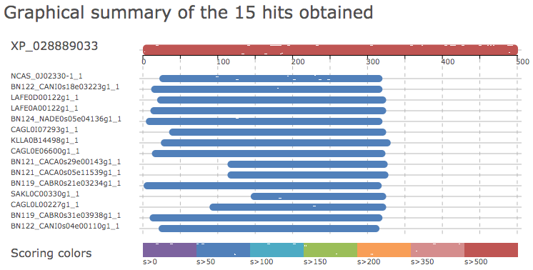

gryc hits

```r
# load the manually edited blast table
gryc <- read_tsv("data/GRYC/XP_028889033_homologs_gryc_table.txt", col_types = cols())
gryc <- gryc %>%
  mutate(species_id = paste0(str_sub(species, 1, 1), word(species, 2, 2)))
gryc %>% select(id, species, length, qcov = query_cover, e_value = min_e_value, max_ident, description)
```

| id | species | length | qcov | e_value | max_ident | description |
| --- | --- | --- | --- | --- | --- | --- |
| XP_003678549 | Naumovozyma castellii CBS 4309 | 773 | 59.481 | 7e-16 | 27.869 | NULL |
| CANI0s18e03223g | Nakaseomyces nivariensis CBS 9983 | 393 | 61.677 | 4e-15 | 29.814 | similar to uniprot\|Q6FQC7\|Q6FQC7_CANGA Candida glabrata CAGL0I07293g Similarity |
| LAFE0D00122g | Lachancea fermentati CBS 6772 | 1347 | 61.078 | 4e-13 | 28.750 | weakly similar to uniprot\|A3LSL7 Scheffersomyces stipitis agglutinin-like protein 2 |
| LAFE0A00122g | Lachancea fermentati CBS 6772 | 673 | 62.874 | 8e-13 | 27.879 | some similarities with uniprot\|A3LSL7 Scheffersomyces stipitis agglutinin-like protein 2 |
| NADE0s05e04136g | Nakaseomyces delphensis CBS 2170 | 409 | 63.074 | 4e-11 | 29.305 | conserved hypothetical protein; partial CDS overlaps gap region; |
| CAGL0I07293g | Candida glabrata CBS 138 | 1771 | 57.884 | 4e-11 | 28.308 | no similarity |
| XP_452176.1 | Kluyveromyces lactis CBS 2359 | 766 | 61.277 | 9e-10 | 27.628 | conserved hypothetical protein |
| CAGL0E06600g | Candida glabrata CBS 138 | 965 | 62.275 | 3e-09 | 28.657 | some similarities with uniprot\|P38894 Saccharomyces cerevisiae YHR211w FLO5 |
| CACA0s29e00143g | Nakaseomyces castellii CBS 4332 | 719 | 42.715 | 2e-07 | 30.603 | weakly similar to uniprot\|A5DD63\|A5DD63_PICGU Pichia guilliermondii PGUG_01214 Putative uncharacterized protein |
| CACA0s05e11539g | Nakaseomyces castellii CBS 4332 | 696 | 42.914 | 2e-07 | 30.472 | weakly similar to uniprot\|Q6FNG1 Candida glabrata CAGL0K00110g |

[output cut: 5 more lines]

*Discussion*

1. For the Ref_seq and fungiDB hits, we applied two additional criteria on top of the E-value cutoff of 1e-5, which are >50% query coverage (280 a.a.) and the protein length > 500 a.a. Let’s see which of the hits will be excluded if we apply the same criteria here.

   | id | species | length | query_cover | min_e_value | max_ident | species_id | description |
   | --- | --- | --- | --- | --- | --- | --- | --- |
   | CANI0s18e03223g | Nakaseomyces nivariensis CBS 9983 | 393 | 61.677 | 4e-15 | 29.814 | Nnivariensis | similar to uniprot\|Q6FQC7\|Q6FQC7_CANGA Candida glabrata CAGL0I07293g Similarity |
   | NADE0s05e04136g | Nakaseomyces delphensis CBS 2170 | 409 | 63.074 | 4e-11 | 29.305 | Ndelphensis | conserved hypothetical protein; partial CDS overlaps gap region; |
   | CACA0s29e00143g | Nakaseomyces castellii CBS 4332 | 719 | 42.715 | 2e-07 | 30.603 | Ncastellii | weakly similar to uniprot\|A5DD63\|A5DD63_PICGU Pichia guilliermondii PGUG_01214 Putative uncharacterized protein |
   | CACA0s05e11539g | Nakaseomyces castellii CBS 4332 | 696 | 42.914 | 2e-07 | 30.472 | Ncastellii | weakly similar to uniprot\|Q6FNG1 Candida glabrata CAGL0K00110g |
   | SAKL0C00330g | Lachancea kluyveri CBS 3082 | 1269 | 36.128 | 5e-07 | 32.632 | Lkluyveri | weakly similar to uniprot\|P40442 Saccharomyces cerevisiae YIL169C Putative protein of unknown function; serine/threonine rich and highly similar to YOL155C, a putative glucan alpha-1,4-glucosidase;tr… |
   | CAGL0L00227g | Candida glabrata CBS 138 | 3241 | 47.106 | 4e-06 | 24.701 | Cglabrata | no similarity |
   | CABR0s31e03938g | Nakaseomyces bracarensis CBS 10154 | 373 | 62.076 | 5e-06 | 25.538 | Nbracarensis | similar to uniprot\|Q6FQC7 Candida glabrata CAGL0I07293g |

2. Among the potentially excluded sequences, I would rescue **NADE0s05e04136g** out of the pile because its short length could be due to the sequence being a “partial CDS”. Another sequence potentially of interest is **CAGL0L00227g**, which has 47% query coverage, and is of similar length as XP_028889033. But latter phylogenetic analysis showed that it appears to have diverged from the homologs with >50% coverage significantly. I therefore decided to maintain the criterion of query coverage over 50% and not include it.
3. Lastly, I’ll remove the hits from *L. fermentati*. This is arbitrary and the rationale is that I just want to get some representation from the Lanchancea genus, and I already have *L. kluyveri*.

## Merge

First we need to find out which sequences were duplicates. To do so we will blast the fungidb and gryc hits against the refseq hits.

> *update 2021-01-25* Added new sequences from the refseq_prot search.

### FungiDB

#### Translate fungiDB IDs to refseq_protein IDs

The first approach I took was to directly blast the fungidb hits to the NCBI refseq_prot database and see how many of them had a match there. Note that due to the way e-values are calculated, a fungidb hit that had an identical match in the refseq_prot database may not actually be among the refseq hits, as we will see below.

See README.md for details on how I did BLAST.

```r
# load blast table
fdb.hits.blast <- read_tsv("data/fungidb/fungidb_blast_refseq_protein.txt", col_names = c("query_id","subject_id","query_length","subject_length","perc_identity","mismatch","score","bitscore","e_value"), col_types = "ccnndnnnn")

# goal: for each fungidb hit, identify the refseq ID that has the highest Score
fdb.hits.blast.filtered <-  fdb.hits.blast %>%
  group_by(query_id) %>%
  filter(score == max(score), str_sub(query_id, -2, -1) != "_B") # this blast was done before I removed the _B alleles

# ID mapping for identical sequences (% identity = 100%)
fdb.refseqID <- fdb.hits.blast.filtered %>% filter(perc_identity == 100) %>% pull(subject_id)
names(fdb.refseqID) <- fdb.hits.blast.filtered %>% filter(perc_identity == 100) %>% pull(query_id)

cat("**Hits not mapped to refseq_prot:**")
```

**Hits not mapped to refseq_prot:**

```r
#fdb.filtered %>% filter(!gene_id %in% names(fdb.refseqID))
fdb.hits.blast.filtered %>%
  filter(perc_identity != 100) %>%
  select(query_id, subject_id, qlen = query_length, slen = subject_length, pident = perc_identity, mismatch, e_value)
```

| query_id | subject_id | qlen | slen | pident | mismatch | e_value |
| --- | --- | --- | --- | --- | --- | --- |
| B9J08_001531 | ref\|XP_028892406.1\| | 1375 | 1375 | 99.687 | 1 | 0.00e+00 |
| B9J08_004098 | ref\|XP_025342839.1\| | 1247 | 1221 | 74.845 | 81 | 1.78e-158 |
| B9J08_004109 | ref\|XP_028889033.1\| | 2946 | 3052 | 95.571 | 24 | 0.00e+00 |
| B9J08_004451 | ref\|XP_028889361.1\| | 717 | 717 | 99.390 | 2 | 0.00e+00 |
| B9J08_004892 | ref\|XP_028888611.1\| | 1720 | 1704 | 93.860 | 5 | 0.00e+00 |
| CPAR2_600430 | ref\|XP_003868555.1\| | 1429 | 774 | 80.802 | 66 | 0.00e+00 |
| CPAR2_806390 | ref\|XP_002421505.1\| | 1640 | 2113 | 53.518 | 300 | 0.00e+00 |
| CPAR2_806410 | ref\|XP_003868553.1\| | 1671 | 706 | 77.076 | 76 | 0.00e+00 |
| CPAR2_806420 | ref\|XP_002418802.1\| | 1714 | 1277 | 55.362 | 154 | 5.06e-95 |
| CTRG_01924 | ref\|XP_002547615.1\| | 827 | 749 | 99.147 | 4 | 0.00e+00 |

*Discussion*

1. Of the 70 sequence, 60 are present in the refseq database.
2. Among the sequences that didn’t map, five belong to the *C. auris* B8441 strain, which is the only strain of *C. auris* present in the FungiDB, but apparently is not in the refseq_protein database. Another three sequences in B8441 apparently are identical to sequences from the other *C. auris* strains included in the refseq database.

#### Search the fungidb hits against a database made of the refseq_prot hits

The above search only identifies fungidb hits that are don’t even have a match in the refseq_prot database. Here we are being more specific and ask which FungiDB hits do not already exist among the refseq_prot hits.

The `bash` script below is to make a blast database from the NCBI blast results and search the FungiDB hits in it to identify matching sequences. Note that we are using all of the N360 hits, including the ones that were filtered out. This is because we are only interested in those FungiDB hits that don’t already exist in the refseq hits at all. So if a hit matches a refseq hit that was later filtered, it would still be excluded.

```bash
# make blast database from the NCBI blast results
cd data
mkdir blastdb
makeblastdb -in ncbi-refseq/XP_028889033_homologs_refprot_N360.fasta -parse_seqids -dbtype prot -title XP_028889033_refprot -out blastdb/XP_028889033_refprot
# blastp
# blastp -db ./blastdb/XP_028889033_refprot -query fungidb/XP_028889033_homologs_fungidb_N360_use.fasta -outfmt "6 qseqid sseqid qlen slen pident mismatch score bitscore evalue" -max_target_seqs 1 -num_threads 4 -out fungidb/XP_028889033_fungidb-refprot-N360-blast.txt
# blastp -db ./blastdb/XP_028889033_refprot -query GRYC/XP_028889033_homologs_gryc.fasta -outfmt "6 qseqid sseqid qlen slen pident mismatch score bitscore evalue" -max_target_seqs 1 -num_threads 4 -out GRYC/XP_028889033_gryc-refprot-N360-blast.txt
blastp -db ./blastdb/XP_028889033_refprot -query fungidb/XP_028889033_homologs_fungidb_N360_use.fasta -outfmt "6 qseqid sseqid qlen slen pident mismatch score bitscore evalue" -evalue 1e-180 -num_threads 4 -out fungidb/XP_028889033_fungidb-refprot-N360-blast-allhits.txt

blastp -db ./blastdb/XP_028889033_refprot -query GRYC/XP_028889033_homologs_gryc.fasta -outfmt "6 qseqid sseqid qlen slen pident mismatch score bitscore evalue" -evalue 1e-180 -num_threads 4 -out GRYC/XP_028889033_gryc-refprot-N360-blast_allhits.txt
```

The typical protocol for identifying orthologs is to perform reciprocol blast. But our goal here is to identify identical sequences – more like what the CDD hits program does – and thus one sided blast should be fine. The analysis below is meant to identify the shared hits as well as the unique hits in each set.

> **===== Update [HB] 2021-06-12 =====**

> The `-max_target_seqs 1` argument to `blastp`, when run locally, led to unexpected behavior – instead of returning the “best” hit ranked by e-value, as one would intuitive expect, it returns the FIRST hit that is above the threshold, and thus the result will also depend on the order of the sequences in the database. This issue is widely documented on the web if one knows what question to search for. See [Shah *et al.* 2019](https://academic.oup.com/bioinformatics/article/35/9/1613/5106166)

> **===== End Update =====**

```r
# local blast the fungiDB hits against the library made from the refseq hits
blast.header <- c("query_id","subject_id","query_length","subject_length","perc_identity","mismatch","score","bitscore","e_value")
fdb2refseq <- read_tsv("data/fungidb/XP_028889033_fungidb-refprot-N360-blast-allhits.txt", col_types = "ccnndnnnn", col_names = blast.header, comment = "#")

# for each query sequence, retain the top hit with the best score
fdb2refseq.best.hit <- fdb2refseq %>%
  group_by(query_id) %>%
  filter(score == max(score))

# if perc_identity is 100, then we had a match
fdb2refseq.match <- fdb2refseq.best.hit %>%
  filter(perc_identity == 100) %>%
  pull(query_id)

# print out some stats
sprintf("When searching %i FungiDB hits in the %i refseq_prot hits, %i got at least one hit.",
        nrow(fdb.filtered), nrow(refseq0), nrow(fdb2refseq.best.hit))
```

[1] “When searching 70 FungiDB hits in the 88 refseq_prot hits, 67 got at least one hit.”

```r
sprintf("Among them, %i FungiDB hits were found to have an identical match in the refseq hits.",
        length(fdb2refseq.match))
```

[1] “Among them, 56 FungiDB hits were found to have an identical match in the refseq hits.”

```r
cat("Below are the FungiDB hits that either had no or non-identical matches in the refseq hits...")
```

Below are the FungiDB hits that either had no or non-identical matches in the refseq hits…

```r
fdb.filtered %>%
  filter(!gene_id %in% fdb2refseq.match) %>%
  select(gene_id, organism, `FDB e_value` = e_value, length) %>%
  left_join(select(fdb2refseq.best.hit, gene_id = query_id, sid = subject_id,
                   slen = subject_length, pident = perc_identity))
```

Joining, by = “gene_id”

| gene_id | organism | FDB e_value | length | sid | slen | pident |
| --- | --- | --- | --- | --- | --- | --- |
| B9J08_001155 | Candida auris strain B8441 | 6e-62 | 858 | ref\|XP_028892087.1\| | 833 | 96.853 |
| B9J08_001531 | Candida auris strain B8441 | 2e-114 | 1375 | ref\|XP_028892406.1\| | 1375 | 99.855 |
| B9J08_004098 | Candida auris strain B8441 | 8e-131 | 1247 | ref\|XP_025342839.1\| | 1221 | 54.782 |
| B9J08_004100 | Candida auris strain B8441 | 2e-127 | 760 | ref\|XP_028887965.1\| | 787 | 96.442 |
| B9J08_004109 | Candida auris strain B8441 | 0e+00 | 2946 | ref\|XP_028889033.1\| | 3052 | 95.611 |
| B9J08_004110 | Candida auris strain B8441 | 3e-127 | 664 | ref\|XP_028889034.1\| | 662 | 99.548 |
| B9J08_004451 | Candida auris strain B8441 | 7e-57 | 717 | ref\|XP_028889361.1\| | 717 | 99.163 |
| B9J08_004892 | Candida auris strain B8441 | 3e-170 | 1720 | ref\|XP_028888611.1\| | 1704 | 99.012 |
| CAGL0L00227g | Candida glabrata CBS 138 | 8e-07 | 3241 | NA | NA | NA |
| CLUG_05233 | Clavispora lusitaniae ATCC 42720 | 6e-09 | 1442 | ref\|XP_002614815.1\| | 674 | 69.298 |

[output cut: 4 more lines]

*Discussion*

1. The top 8 are from B8441 of *C. auris*. As noted above, the refseq strain for the species is B11221. Looking at the perc_identity of the matches, we can see that B11221 misses one of the eight hits in B8441, i.e. B9J08_004098.
2. CAGL0L00227g and CLUG_05233 are both “provisional” refseq sequences, meaning that their records have not been submitted to NCBI for final review.
3. I will use the refseq hits as the base and add *C. auris* B9J08_004098, CLUG_05233 and the *C. parapsilosis* sequences (for some reason this species is not included in refseq). To do so, I’ll use the `read.fasta()` function from the `seqinr` package to extract their sequences, and use the `write.fasta()` function to output the combined fasta.

> **Update 2020-10-18** I realized that by including the one sequence from *C. auris* B8441, the final dataset would contain two *C. auris* strains, making it distinct from the other species, each of which is represented by one strain only. This wouldn’t change the broader conclusions. But if there is a need to modify the homologs list and repeat the downstream analysis, I would like to remove this sequence (B9J08_004098)

> **Update 2021-03-01** I will actually include B9J08_004098. See notes in the fungidb blast section above and also README.md in this folder for reasons.